# Report_2

Arturo Bertero

2026-02-25

# 1 Introduction

This short report focuses on the new multilevel models.

Minor changes w/ respect to old report:

1. Data is weighted
2. I have imported second-last election turnout
3. I am doing the test for random slopes justification
4. I am doing many more multilevel models

## 1.1 Models I am running

| Name | Structure (fixed effects + random effects) |
| --- | --- |
| **MM0: Intercept Only** | Fixed: `lon_centered + gender + age_decades_centered + educ + hhincome` \| Random: `(1 \| cntry)` |
| **MM1: Random Slopes** | Fixed: `lon_centered + gender + age_decades_centered + educ + hhincome` \| Random: `(1 + lon_centered \| cntry)` |
| **MM2: Additive Penalties** | Fixed: `lon_centered + si_centered + gender + age_decades_centered + educ + hhincome` \| Random: `(1 + lon_centered + si_centered \| cntry)` |
| **MM3: Interaction** | Fixed: `lon_centered * si_centered + gender + age_decades_centered + educ + hhincome` \| Random: `(1 + lon_centered + si_centered \| cntry)` |
| **MM4: Typology** | Fixed: `sil_type + gender + age_decades_centered + educ + hhincome` \| Random: `(1 \| cntry)` |
| **MM5: Robustness Controls** | Fixed: `lon_centered + si_centered + polint_centered + partisanship + gender + age_decades_centered + educ + hhincome` \| Random: `(1 + lon_centered + si_centered \| cntry)` |
| **MM6: Macro Interaction** | Fixed: `lon_centered * official_turnout_lag + si_centered + polint_centered + partisanship + gender + age_decades_centered + educ + hhincome` \| Random: `(1 + lon_centered + si_centered \| cntry)` |
| **MM7: Macro Control (Standard DV)** | Fixed: `lon_centered + si_centered + polint_centered + partisanship + official_turnout_lag + gender + age_decades_centered + educ + hhincome` \| Random: `(1 + lon_centered + si_centered \| cntry)` |
| **MM8: Macro Control (Strict DV)** | Fixed: `lon_centered + si_centered + polint_centered + partisanship + official_turnout_lag + gender + age_decades_centered + educ + hhincome` \| Random: `(1 + lon_centered + si_centered \| cntry)` |

## 1.2 Summary of results

- Loneliness is associated with turnout
- Social isolation adds to loneliness, but no interaction
- Hence, the typology var works (high L high SI are the least likely to vote)
- These findings hold when considering partisanship and political interest
- Lagged official turnout shares are important, but do not moderate the loneliness-turnout link

## 1.3 Results

### 1.3.1 Justifying random slopes for L and SI

Below the output of a likelihood ratio test. The logic is to start from a simpler specification and then ask whether allowing additional country-level heterogeneity significantly improves model fit.

In this first test we are comaparing the basiline model with and without random slopes for L. Since the test is significant we should model random slopes for L.

| Model | Random effects structure | npar | AIC | BIC | logLik | -2*log(L) | Chisq | Df | Pr(>Chisq) |
| --- | --- | --- | --- | --- | --- | --- | --- | --- | --- |
| **mm0_intercept** | `(1 \\| cntry)` | 10 | 38095 | 38182 | -19037 | 38075 |  |  |  |
| **mm1_base** | `(1 + lon_centered \\| cntry)` | 12 | 37954 | 38058 | -18965 | 37930 | 145.03 | 2 | < 2.2e-16 *** |

I now extend the same logic comparing:

1. random intercept only
2. random intercept + random slopes for L
3. random intercept + random slopes for L + random slopes for SI

We should use both!

| Model | Random effects structure | npar | AIC | BIC | logLik | -2*log(L) | ΔChisq | ΔDf | Pr(>Chisq) |
| --- | --- | --- | --- | --- | --- | --- | --- | --- | --- |
| **test0_intercept** | `(1 \\| cntry)` | 11 | 37617 | 37713 | -18798 | 37595 |  |  |  |
| **test1_lon_slope** | `(1 + lon_centered \\| cntry)` | 13 | 37487 | 37600 | -18730 | 37461 | 134.481 | 2 | < 2.2e-16 *** |
| **test2_both_slopes** | `(1 + lon_centered + si_centered \\| cntry)` | 16 | 37424 | 37563 | -18696 | 37392 | 69.252 | 3 | 6.173e-15 *** |

### 1.3.2 MM0-MM1

Table S1: Justification of Random Slopes for Loneliness

|  | MM0: Intercept Only |  |  | MM1: Random Slopes |  |  |
| --- | --- | --- | --- | --- | --- | --- |
| Predictors | Odds Ratios | CI | p | Odds Ratios | CI | p |
| Intercept | 2.60 | 2.10 – 3.21 | **<0.001** | 2.61 | 2.11 – 3.24 | **<0.001** |
| Loneliness (Centered) | 0.71 | 0.69 – 0.74 | **<0.001** | 0.72 | 0.66 – 0.79 | **<0.001** |
| Gender (Female) | 0.86 | 0.82 – 0.91 | **<0.001** | 0.86 | 0.82 – 0.90 | **<0.001** |
| Age (Decades, Centered) | 1.36 | 1.34 – 1.38 | **<0.001** | 1.37 | 1.35 – 1.39 | **<0.001** |
| Education: Medium | 2.04 | 1.91 – 2.18 | **<0.001** | 2.02 | 1.89 – 2.16 | **<0.001** |
| Education: High | 3.66 | 3.39 – 3.95 | **<0.001** | 3.64 | 3.37 – 3.92 | **<0.001** |
| hhincomeCoping on present income | 0.75 | 0.70 – 0.79 | **<0.001** | 0.75 | 0.71 – 0.80 | **<0.001** |
| hhincomeDifficult on present income | 0.66 | 0.61 – 0.71 | **<0.001** | 0.67 | 0.62 – 0.72 | **<0.001** |
| hhincomeVery difficult on present income | 0.61 | 0.54 – 0.68 | **<0.001** | 0.61 | 0.54 – 0.69 | **<0.001** |
| Random Effects |  |  |  |  |  |  |
| σ<sup>2</sup> | 3.29 |  |  | 3.29 |  |  |
| τ<sub>00</sub> | 0.28 <sub>cntry</sub> |  |  | 0.28 <sub>cntry</sub> |  |  |
| τ<sub>11</sub> |  |  |  | 0.03 <sub>cntry.lon_centered</sub> |  |  |
| ρ<sub>01</sub> |  |  |  | -0.24 <sub>cntry</sub> |  |  |
| ICC | 0.08 |  |  | 0.08 |  |  |
| N | 30 <sub>cntry</sub> |  |  | 30 <sub>cntry</sub> |  |  |
| Observations | 44315 |  |  | 44315 |  |  |
| Marginal R<sup>2</sup> / Conditional R<sup>2</sup> | 0.124 / 0.192 |  |  | 0.123 / 0.195 |  |  |

- MM0 and MM1 compare a random-intercept specification to a model that also allows the loneliness slope to vary across countries.
- The random slope variance for lon_centered is non-zero: we should do random slope
- loneliness is negatively associated with turnout across the EU

### 1.3.3 MM2

Table 2: Multilevel Model - Additive Social Deficits

|  | MM2: Additive Penalties |  |  |
| --- | --- | --- | --- |
| Predictors | Odds Ratios | CI | p |
| Intercept | 2.71 | 2.17 – 3.39 | **<0.001** |
| Loneliness (Centered) | 0.79 | 0.72 – 0.86 | **<0.001** |
| Social Isolation (Centered) | 0.70 | 0.66 – 0.74 | **<0.001** |
| Gender (Female) | 0.82 | 0.77 – 0.86 | **<0.001** |
| Age (Decades, Centered) | 1.40 | 1.38 – 1.42 | **<0.001** |
| Education: Medium | 1.97 | 1.84 – 2.11 | **<0.001** |
| Education: High | 3.40 | 3.15 – 3.67 | **<0.001** |
| hhincomeCoping on present income | 0.79 | 0.74 – 0.84 | **<0.001** |
| hhincomeDifficult on present income | 0.72 | 0.67 – 0.78 | **<0.001** |
| hhincomeVery difficult on present income | 0.69 | 0.61 – 0.78 | **<0.001** |
| Random Effects |  |  |  |
| σ<sup>2</sup> | 3.29 |  |  |
| τ<sub>00</sub> <sub>cntry</sub> | 0.31 |  |  |
| τ<sub>11</sub> <sub>cntry.lon_centered</sub> | 0.03 |  |  |
| τ<sub>11</sub> <sub>cntry.si_centered</sub> | 0.01 |  |  |
| ρ<sub>01</sub> | -0.12 |  |  |
|  | -0.82 |  |  |
| ICC | 0.09 |  |  |
| N <sub>cntry</sub> | 30 |  |  |
| Observations | 44315 |  |  |
| Marginal R<sup>2</sup> / Conditional R<sup>2</sup> | 0.146 / 0.223 |  |  |

- Adding social isolation shows that both loneliness and social isolation independently predict lower turnout

Caterpillar plot for the intercept

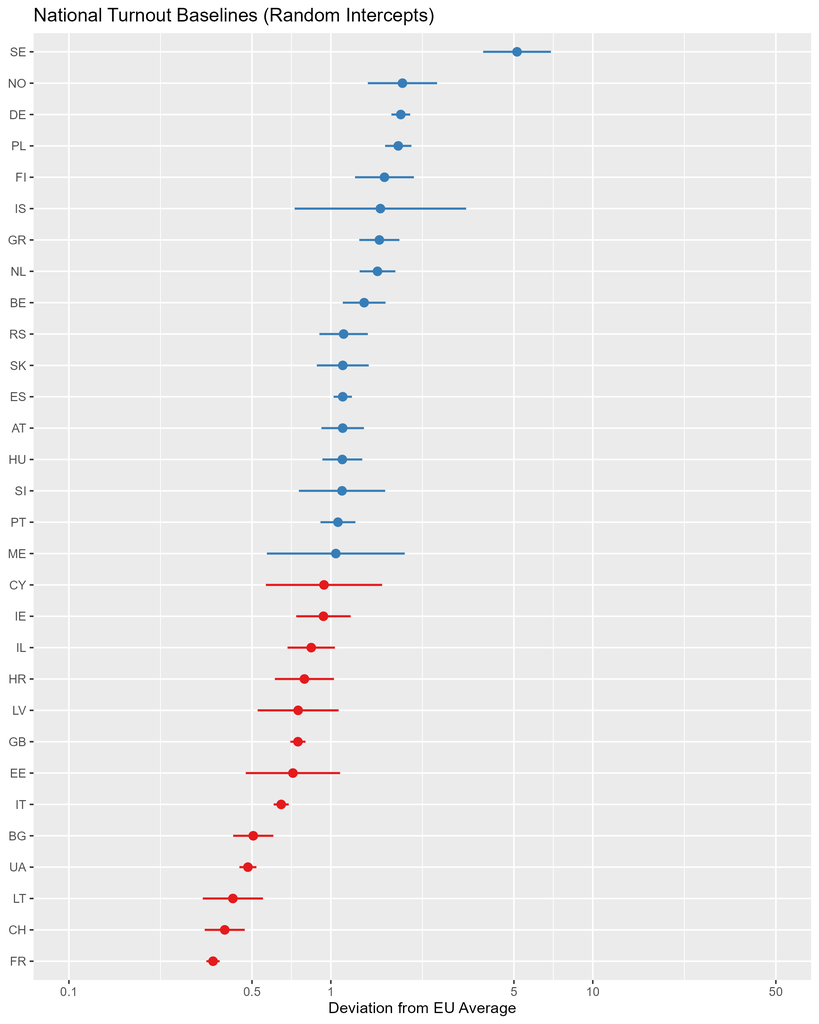

Caterpillar plot for the random slopes of L

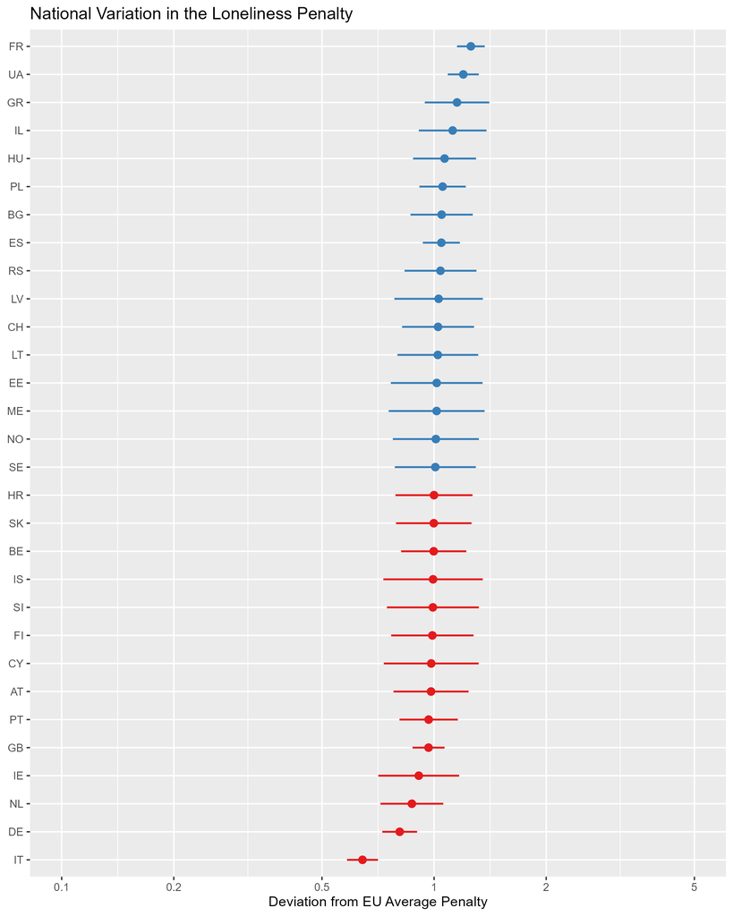

Caterpillar plot for the random slopes of SI

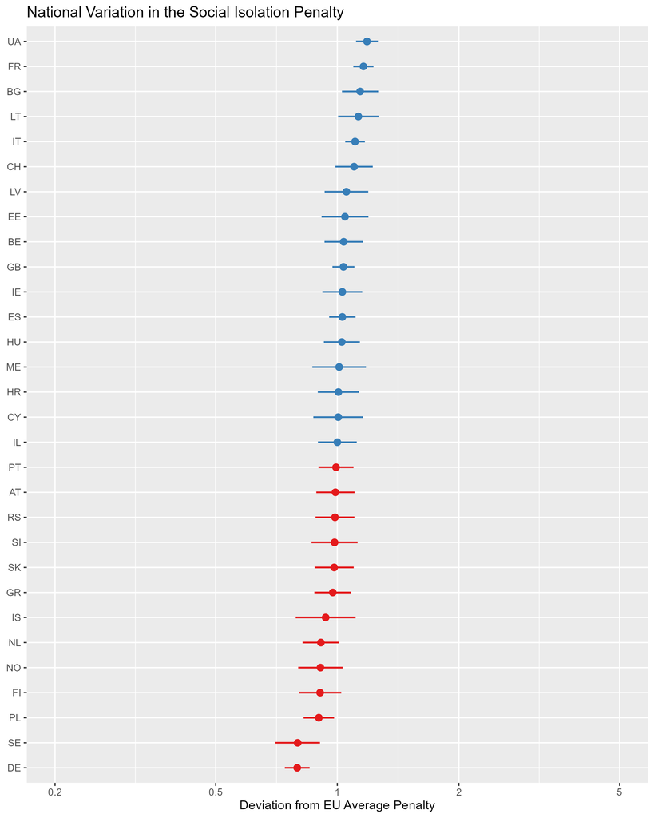

### 1.3.4 MM3

Table 3: Multilevel Model - The Double Burden Interaction

|  | MM3: Interaction |  |  |
| --- | --- | --- | --- |
| Predictors | Odds Ratios | CI | p |
| Intercept | 2.71 | 2.17 – 3.39 | **<0.001** |
| Loneliness (Centered) | 0.78 | 0.71 – 0.86 | **<0.001** |
| Social Isolation (Centered) | 0.70 | 0.66 – 0.74 | **<0.001** |
| Gender (Female) | 0.82 | 0.77 – 0.86 | **<0.001** |
| Age (Decades, Centered) | 1.40 | 1.37 – 1.42 | **<0.001** |
| Education: Medium | 1.97 | 1.84 – 2.11 | **<0.001** |
| Education: High | 3.40 | 3.15 – 3.67 | **<0.001** |
| hhincomeCoping on present income | 0.79 | 0.74 – 0.84 | **<0.001** |
| hhincomeDifficult on present income | 0.72 | 0.67 – 0.79 | **<0.001** |
| hhincomeVery difficult on present income | 0.69 | 0.61 – 0.78 | **<0.001** |
| Interaction: Lon x SI | 1.01 | 0.97 – 1.05 | 0.560 |
| Random Effects |  |  |  |
| σ<sup>2</sup> | 3.29 |  |  |
| τ<sub>00</sub> <sub>cntry</sub> | 0.31 |  |  |
| τ<sub>11</sub> <sub>cntry.lon_centered</sub> | 0.03 |  |  |
| τ<sub>11</sub> <sub>cntry.si_centered</sub> | 0.01 |  |  |
| ρ<sub>01</sub> | -0.12 |  |  |
|  | -0.82 |  |  |
| ICC | 0.09 |  |  |
| N <sub>cntry</sub> | 30 |  |  |
| Observations | 44315 |  |  |
| Marginal R<sup>2</sup> / Conditional R<sup>2</sup> | 0.146 / 0.223 |  |  |

- The interaction term is not significant: SI and L do not multiply each other
- loneliness and isolation only operate additively

Non significant interaction plot

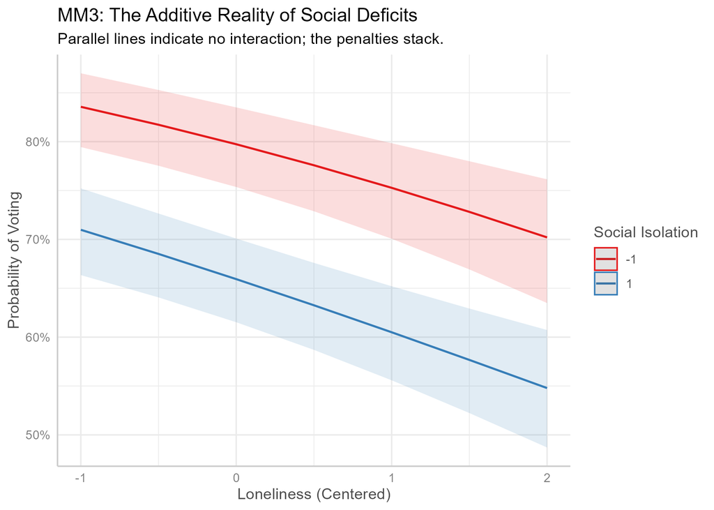

### 1.3.5 MM4

Table 4: Multilevel Model - Social Isolation & Loneliness Typology

|  | MM4: Typology |  |  |
| --- | --- | --- | --- |
| Predictors | Odds Ratios | CI | p |
| (Intercept) | 3.40 | 2.76 – 4.19 | **<0.001** |
| sil type: Low L,High SI | 0.64 | 0.59 – 0.69 | **<0.001** |
| sil type: High L,Low SI | 0.73 | 0.68 – 0.78 | **<0.001** |
| sil type: High L,High SI | 0.41 | 0.38 – 0.44 | **<0.001** |
| gender: Female | 0.83 | 0.79 – 0.87 | **<0.001** |
| age decades centered | 1.39 | 1.37 – 1.41 | **<0.001** |
| educ: Medium | 2.03 | 1.90 – 2.17 | **<0.001** |
| educ: High | 3.54 | 3.28 – 3.82 | **<0.001** |
| hhincome: Coping on present income | 0.76 | 0.72 – 0.81 | **<0.001** |
| hhincome: Difficult on present income | 0.69 | 0.63 – 0.74 | **<0.001** |
| hhincome: Very difficult on present income | 0.64 | 0.57 – 0.72 | **<0.001** |
| Random Effects |  |  |  |
| σ<sup>2</sup> | 3.29 |  |  |
| τ<sub>00</sub> <sub>cntry</sub> | 0.26 |  |  |
| ICC | 0.07 |  |  |
| N <sub>cntry</sub> | 30 |  |  |
| Observations | 44315 |  |  |
| Marginal R<sup>2</sup> / Conditional R<sup>2</sup> | 0.139 / 0.201 |  |  |

- The group with high L and high SI is the most disengaged

Predicted turnout by SIL levels

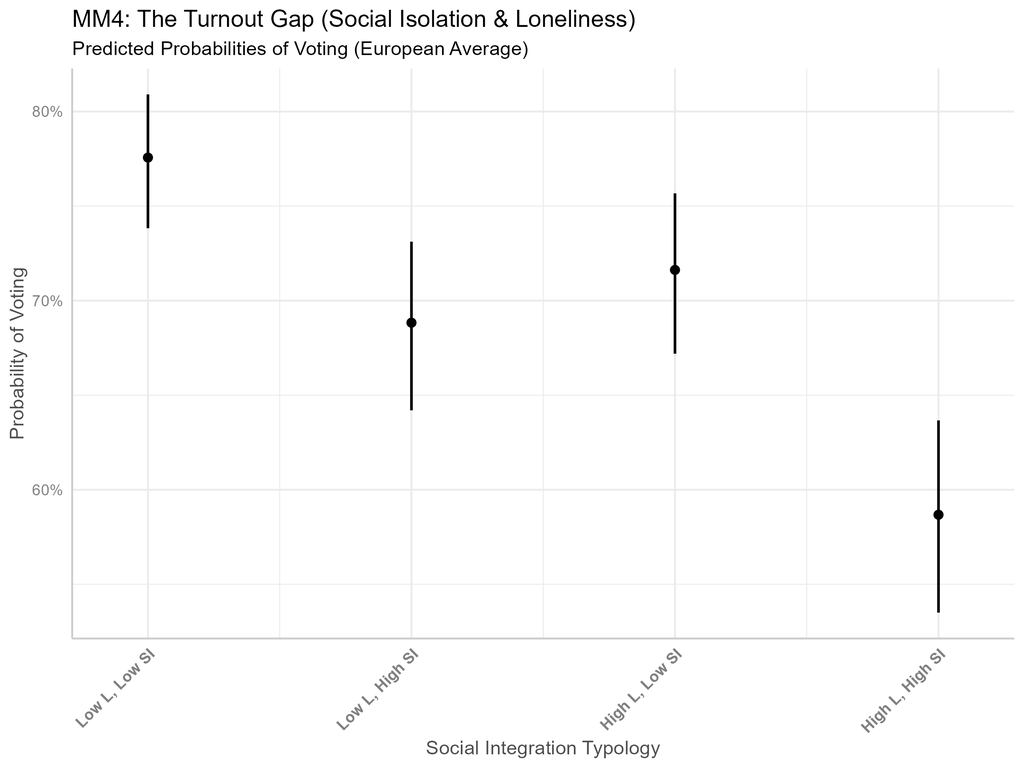

### 1.3.6 MM5

Table 5: Multilevel Model - Robustness with Political Motivation

|  | MM5: Robustness Controls |  |  |
| --- | --- | --- | --- |
| Predictors | Odds Ratios | CI | p |
| Intercept | 1.91 | 1.53 – 2.39 | **<0.001** |
| Loneliness (Centered) | 0.76 | 0.70 – 0.83 | **<0.001** |
| Social Isolation (Centered) | 0.77 | 0.72 – 0.82 | **<0.001** |
| Pol. Interest (Centered) | 1.77 | 1.71 – 1.83 | **<0.001** |
| partisanship | 3.24 | 3.03 – 3.46 | **<0.001** |
| Gender (Female) | 1.03 | 0.97 – 1.08 | 0.363 |
| Age (Decades, Centered) | 1.31 | 1.29 – 1.33 | **<0.001** |
| Education: Medium | 1.70 | 1.58 – 1.82 | **<0.001** |
| Education: High | 2.38 | 2.19 – 2.58 | **<0.001** |
| hhincomeCoping on present income | 0.90 | 0.84 – 0.96 | **0.001** |
| hhincomeDifficult on present income | 0.83 | 0.77 – 0.91 | **<0.001** |
| hhincomeVery difficult on present income | 0.80 | 0.70 – 0.91 | **0.001** |
| Random Effects |  |  |  |
| σ<sup>2</sup> | 3.29 |  |  |
| τ<sub>00</sub> <sub>cntry</sub> | 0.30 |  |  |
| τ<sub>11</sub> <sub>cntry.lon_centered</sub> | 0.02 |  |  |
| τ<sub>11</sub> <sub>cntry.si_centered</sub> | 0.01 |  |  |
| ρ<sub>01</sub> | -0.02 |  |  |
|  | -0.72 |  |  |
| ICC | 0.09 |  |  |
| N <sub>cntry</sub> | 30 |  |  |
| Observations | 43284 |  |  |
| Marginal R<sup>2</sup> / Conditional R<sup>2</sup> | 0.286 / 0.348 |  |  |

- Political interest and partisanship work
- But L and SI remain significant

Coefficient plot:

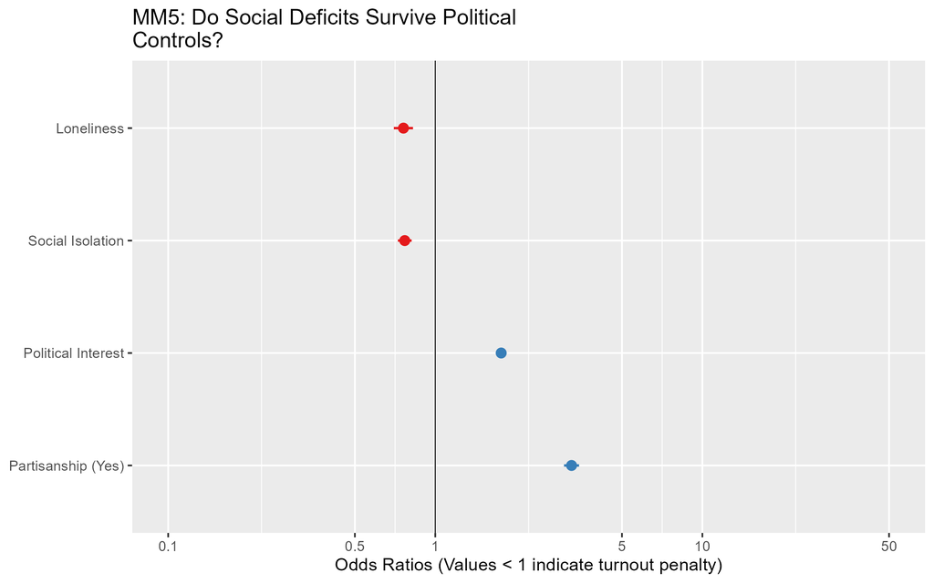

### 1.3.7 M6

Table 6: Multilevel Model - Cross-Level Moderation by National Turnout

|  | MM6: Macro Interaction |  |  |
| --- | --- | --- | --- |
| Predictors | Odds Ratios | CI | p |
| Intercept | 0.30 | 0.13 – 0.69 | **0.005** |
| Loneliness (Centered) | 1.11 | 0.68 – 1.80 | 0.682 |
| Official Turnout (Lagged) | 17.11 | 4.86 – 60.18 | **<0.001** |
| Social Isolation (Centered) | 0.76 | 0.71 – 0.81 | **<0.001** |
| Pol. Interest (Centered) | 1.77 | 1.71 – 1.83 | **<0.001** |
| partisanship | 3.23 | 3.03 – 3.45 | **<0.001** |
| Gender (Female) | 1.03 | 0.97 – 1.08 | 0.357 |
| Age (Decades, Centered) | 1.31 | 1.29 – 1.33 | **<0.001** |
| Education: Medium | 1.70 | 1.58 – 1.83 | **<0.001** |
| Education: High | 2.38 | 2.19 – 2.59 | **<0.001** |
| hhincomeCoping on present income | 0.90 | 0.84 – 0.96 | **0.002** |
| hhincomeDifficult on present income | 0.84 | 0.77 – 0.92 | **<0.001** |
| hhincomeVery difficult on present income | 0.80 | 0.71 – 0.92 | **0.001** |
| Cross-Level: Lon x Turnout Lag | 0.57 | 0.28 – 1.18 | 0.132 |
| Random Effects |  |  |  |
| σ<sup>2</sup> | 3.29 |  |  |
| τ<sub>00</sub> <sub>cntry</sub> | 0.18 |  |  |
| τ<sub>11</sub> <sub>cntry.lon_centered</sub> | 0.01 |  |  |
| τ<sub>11</sub> <sub>cntry.si_centered</sub> | 0.01 |  |  |
| ρ<sub>01</sub> | 0.19 |  |  |
|  | -0.61 |  |  |
| ICC | 0.06 |  |  |
| N <sub>cntry</sub> | 30 |  |  |
| Observations | 43284 |  |  |
| Marginal R<sup>2</sup> / Conditional R<sup>2</sup> | 0.319 / 0.357 |  |  |

- This model is the one with the lagged national turnout
- The cross level interaction is not significant
- This is amazing, cause it says that SIL -> turnout works like a strong psychological mechanism: it works regardless of national turnout habbits

### 1.3.8 MM7 and MM8

Table 7: Robustness Checks - Macro Controls and Strict Turnout

|  | Standard Vote Recall |  |  | Strict Vote Recall (Party Named) |  |  |
| --- | --- | --- | --- | --- | --- | --- |
| Predictors | Odds Ratios | CI | p | Odds Ratios | CI | p |
| Intercept | 0.29 | 0.12 – 0.68 | **0.004** | 0.16 | 0.07 – 0.38 | **<0.001** |
| Loneliness (Centered) | 0.77 | 0.70 – 0.83 | **<0.001** | 0.88 | 0.81 – 0.95 | **0.001** |
| Social Isolation (Centered) | 0.76 | 0.72 – 0.81 | **<0.001** | 0.84 | 0.81 – 0.87 | **<0.001** |
| Pol. Interest (Centered) | 1.77 | 1.71 – 1.83 | **<0.001** | 1.67 | 1.62 – 1.72 | **<0.001** |
| partisanship | 3.23 | 3.03 – 3.45 | **<0.001** | 3.19 | 3.03 – 3.37 | **<0.001** |
| Official Turnout (Lagged) | 18.18 | 5.02 – 65.79 | **<0.001** | 18.34 | 5.12 – 65.67 | **<0.001** |
| Gender (Female) | 1.03 | 0.97 – 1.08 | 0.356 | 1.06 | 1.01 – 1.12 | **0.015** |
| Age (Decades, Centered) | 1.31 | 1.29 – 1.33 | **<0.001** | 1.18 | 1.17 – 1.20 | **<0.001** |
| Education: Medium | 1.70 | 1.58 – 1.83 | **<0.001** | 1.43 | 1.34 – 1.53 | **<0.001** |
| Education: High | 2.38 | 2.19 – 2.59 | **<0.001** | 1.68 | 1.56 – 1.81 | **<0.001** |
| hhincomeCoping on present income | 0.90 | 0.84 – 0.96 | **0.001** | 0.80 | 0.76 – 0.85 | **<0.001** |
| hhincomeDifficult on present income | 0.84 | 0.77 – 0.92 | **<0.001** | 0.79 | 0.73 – 0.85 | **<0.001** |
| hhincomeVery difficult on present income | 0.80 | 0.71 – 0.92 | **0.001** | 0.76 | 0.67 – 0.85 | **<0.001** |
| Random Effects |  |  |  |  |  |  |
| σ<sup>2</sup> | 3.29 |  |  | 3.29 |  |  |
| τ<sub>00</sub> | 0.18 <sub>cntry</sub> |  |  | 0.17 <sub>cntry</sub> |  |  |
| τ<sub>11</sub> | 0.02 <sub>cntry.lon_centered</sub> |  |  | 0.02 <sub>cntry.lon_centered</sub> |  |  |
|  | 0.01 <sub>cntry.si_centered</sub> |  |  | 0.00 <sub>cntry.si_centered</sub> |  |  |
| ρ<sub>01</sub> | 0.19 |  |  | 0.12 |  |  |
|  | -0.61 |  |  | -0.27 |  |  |
| ICC | 0.06 |  |  |  |  |  |
| N | 30 <sub>cntry</sub> |  |  | 30 <sub>cntry</sub> |  |  |
| Observations | 43284 |  |  | 43284 |  |  |
| Marginal R<sup>2</sup> / Conditional R<sup>2</sup> | 0.320 / 0.358 |  |  | 0.274 / NA |  |  |

- When removing the interaction, L is significant again
- Our main effects hold when using a stricter DV

Coefficient plot:

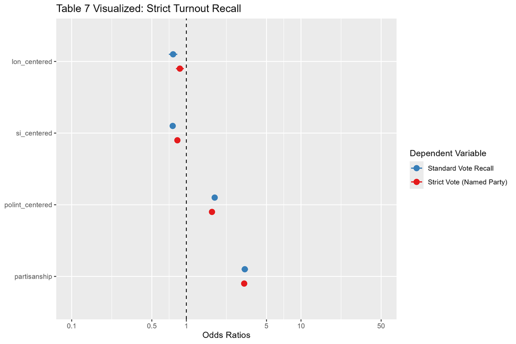